# Вариант 16.

### Копылов Виталий Ярославовович. гр. в3530904/00022

# Задание 1

Для заданной функции $f(x)$ построить интерполяционный полином $P(x)$ в форме Лагранжа по точкам $x_0, x_1, x_2, x_3$ и нарисовать график погрешности $r(x) = f(x) - P(x)$. График построить с помощью любого приложения с соблюдением подходящих диапазонов $cos(Pi*x)/2$: по координате х взять интервал близкий к $[x_0,x_3]$, по вертикальной оси диапазон должен быть близким к $[r_{min}, r_{max}]$. Коэффициенты полинома получить с 7-мю значащими цифрами.

### Функция: $$cos(Pi*x)/2$$

$x_0$ = 0

$x_1$ = 1/6

$x_2$ = 1/4

$x_3$ = 1/3

# Начало исследования

```python
import numpy as np
import matplotlib.pyplot as plt
import scipy.special
import functools
%matplotlib inline
```

### Вычисление исходной функции и построение графика

```python
def f(x: np.longdouble) -> np.longdouble:
    return np.longdouble(
        np.cos(np.pi * x) / np.longdouble(2.0)
    )

# func results
x = np.array(
    [np.longdouble(0), np.longdouble(1/6), np.longdouble(1/4), np.longdouble(1/3)],
    dtype = np.longdouble)

y = np.array(list(map(f, x)), dtype = np.longdouble)

for point, res in zip(x,y):
    print('x: {0:2.7f} y: {1:2.7f}'.format(point, res))
```

```
x: 0.0000000 y: 0.5000000
x: 0.1666667 y: 0.4330127
x: 0.2500000 y: 0.3535534
x: 0.3333333 y: 0.2500000
```

### Построение полинома Лагранжа по данным точкам и его график

Для текущих 4-ех узлов, необходимо построить полином Лагранжа 3-ей степени, поэтому его вид станет: $$ L(x) = \sum_{i=0}^{3} f_i * b_i(x)$$ где $b_i(x)$ является $b_i(x) = \prod_{j=0, i \neq j}^{n} \frac{x - x_j}{x_i - x_j}$

Исходя из этого исходный полином примет вид:

$$ L(x) = \sum_{i=0}^{3} f_i * b_i(x) = f_0 * \frac{(x - x_1) * (x - x_2) * (x - x_3)}{(x_0 - x_1) * (x_0 - x_2) * (x_0 - x_3)} + f_1 * \frac{(x - x_0) * (x - x_2) * (x - x_3)}{(x_1 - x_0) * (x_1 - x_2) * (x_1 - x_3)} + f_2 * \frac{(x - x_0) * (x - x_1) * (x - x_3)}{(x_2 - x_0) * (x_2 - x_1) * (x_2 - x_3)} + f_3 * \frac{(x - x_0) * (x - x_1) * (x - x_2)}{(x_3 - x_0) * (x_3 - x_1) * (x_3 - x_2)}$$

```python
def La(x, y, unit:np.longdouble) -> np.longdouble:
    """
    Многочлен Лагранжа

    Параметры:
    x - вектор двойной точности узлов функции f(x)
    y - вектор двойной точности результатов функции f(x)
    unit - произвольный узел, для которого находится значения

    return: np.longdouble - значение функции в произвольном узле unit
    """
    res = 0
    for i in range(len(x)):
        prod_up = y[i]
        prod_down = np.longdouble(1.0)

        for j in range(len(x)):
            if i != j:
                prod_up *= unit - x[j]
                prod_down *= x[i] - x[j]
        res += prod_up / prod_down

    return res

# func results
y_La = []
for i in x:
    y_La.append(La(x, y, i))

for point, res in zip(x,y_La):
    print('x: {0:2.7f} y: {1:2.7f}'.format(point, res))
```

```
x: 0.0000000 y: 0.5000000
x: 0.1666667 y: 0.4330127
x: 0.2500000 y: 0.3535534
x: 0.3333333 y: 0.2500000
```

### Графики функции и полинома Лагранжа:

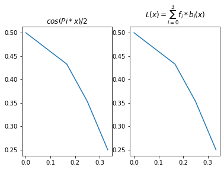

```python
# отдельные графики
plt.subplot(121)
plt.plot(x, y)
plt.title('$cos(Pi*x)/2$')
plt.subplot(122)
plt.plot(x, y_La)
plt.title('$L(x) = \sum_{i=0}^{3} f_i * b_i(x)$')
```

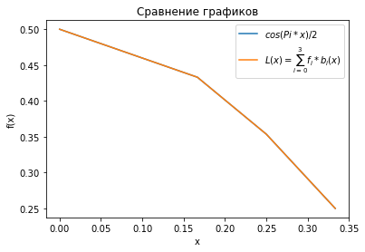

```python
plt.plot(x, y, label = '$cos(Pi*x)/2$')
plt.plot(x, y_La, label = '$L(x) = \sum_{i=0}^{3} f_i * b_i(x)$')

plt.legend()
plt.xlabel('x')
plt.ylabel('f(x)')
plt.title('Сравнение графиков')
```

### Вычисление погрешности и построение графика погрешности

```python
list(zip([1,2], [3,4], [5,6]))
```

```
[(1, 3, 5), (2, 4, 6)]
```

```python
xr = np.linspace(x.min(), x.max(), 30)
y_for_fx_xr = np.array([f(unit) for unit in xr], dtype=np.longdouble)
y_for_La_xr = np.array([La(xr, y_for_fx_xr, unit) for unit in xr], dtype=np.longdouble)
r = abs(y_for_fx_xr - y_for_La_xr)
for point, res_for_fx, res_for_La, r_dist in zip(xr,y_for_fx_xr, y_for_La_xr, r):
    print('x= {0:3.7f} f(x)= {1:3.7f} L(x)= {2:3.7f} r = {3:3.7e}'.format(point, res_for_fx, res_for_La, r_dist))
```

```
x= 0.0000000 f(x)= 0.5000000 L(x)= 0.5000000 r = 0.0000000e+00
x= 0.0114943 f(x)= 0.4996740 L(x)= 0.4996740 r = 1.0842022e-19
x= 0.0229885 f(x)= 0.4986966 L(x)= 0.4986966 r = 0.0000000e+00
x= 0.0344828 f(x)= 0.4970690 L(x)= 0.4970690 r = 8.1315163e-20
x= 0.0459770 f(x)= 0.4947933 L(x)= 0.4947933 r = 0.0000000e+00
x= 0.0574713 f(x)= 0.4918724 L(x)= 0.4918724 r = 0.0000000e+00
x= 0.0689655 f(x)= 0.4883103 L(x)= 0.4883103 r = 5.4210109e-20
x= 0.0804598 f(x)= 0.4841115 L(x)= 0.4841115 r = 1.0842022e-19
x= 0.0919540 f(x)= 0.4792815 L(x)= 0.4792815 r = 5.4210109e-20
x= 0.1034483 f(x)= 0.4738266 L(x)= 0.4738266 r = 1.0842022e-19
x= 0.1149425 f(x)= 0.4677539 L(x)= 0.4677539 r = 5.4210109e-20
x= 0.1264368 f(x)= 0.4610714 L(x)= 0.4610714 r = 0.0000000e+00
x= 0.1379310 f(x)= 0.4537877 L(x)= 0.4537877 r = 1.0842022e-19
x= 0.1494253 f(x)= 0.4459124 L(x)= 0.4459124 r = 8.1315163e-20
x= 0.1609195 f(x)= 0.4374557 L(x)= 0.4374557 r = 0.0000000e+00
x= 0.1724138 f(x)= 0.4284286 L(x)= 0.4284286 r = 2.7105054e-20
x= 0.1839080 f(x)= 0.4188429 L(x)= 0.4188429 r = 5.4210109e-20
x= 0.1954023 f(x)= 0.4087112 L(x)= 0.4087112 r = 0.0000000e+00
x= 0.2068966 f(x)= 0.3980465 L(x)= 0.3980465 r = 2.7105054e-20
x= 0.2183908 f(x)= 0.3868629 L(x)= 0.3868629 r = 5.4210109e-20
x= 0.2298851 f(x)= 0.3751749 L(x)= 0.3751749 r = 1.0842022e-19
x= 0.2413793 f(x)= 0.3629977 L(x)= 0.3629977 r = 0.0000000e+00
x= 0.2528736 f(x)= 0.3503473 L(x)= 0.3503473 r = 8.1315163e-20
x= 0.2643678 f(x)= 0.3372401 L(x)= 0.3372401 r = 5.4210109e-20
x= 0.2758621 f(x)= 0.3236931 L(x)= 0.3236931 r = 2.7105054e-20
x= 0.2873563 f(x)= 0.3097242 L(x)= 0.3097242 r = 0.0000000e+00
x= 0.2988506 f(x)= 0.2953514 L(x)= 0.2953514 r = 0.0000000e+00
x= 0.3103448 f(x)= 0.2805935 L(x)= 0.2805935 r = 1.3552527e-19
x= 0.3218391 f(x)= 0.2654698 L(x)= 0.2654698 r = 5.4210109e-20
x= 0.3333333 f(x)= 0.2500000 L(x)= 0.2500000 r = 0.0000000e+00
```

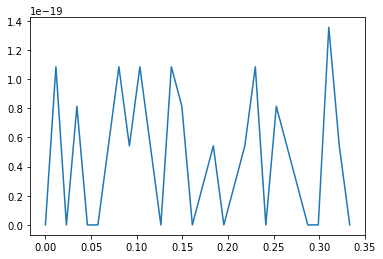

```python
plt.plot(xr, r, label = '$f(x) - L(x)')
```

# Задание 2

Для заданной функции $f(x)$ оценить в точке $x^*$ погрешность интерполирования по точкам $x_0, x_1, x_2, x_3$. Привести все необходимые формулы. Результат представить в десятичной форме с тремя значащими цифрами. Сравнить оценку погрешности с модулем реальной погрешностью в точке $x^*$. $$x^* = \frac{11}{48}$$

## Начало исследования

$f(x) = cos(Pi*x)/2$

$f^{1}(x) = - \frac{1}{2} * Pi * sin(Pi*x)$

$f^{2}(x) = - \frac{1}{2} * Pi^2 * cos(Pi*x)$

$f^{3}(x) = \frac{1}{2} * Pi^3 * sin(Pi*x)$

### Вычисление максимального значения $M_{n+1}$ в $x_1, ..., x_3$ для $f^{(3)}(x)$ и $\omega(x^*)$

```python
def f_derivative_3(x: np.longdouble) -> np.longdouble:
    return np.longdouble(
        np.longdouble(0.5) * np.power(np.pi, 3) * np.sin(np.pi * x)
    )

M = [f_derivative_3(unit) for unit in x]
M_max = max(M)

for unit, m in zip(x, M):
    print(f'x = {unit:3.7f} m = {m:3.7f}')
else:
    print(f'M max = {M_max}')
```

```
x = 0.0000000 m = 0.0000000
x = 0.1666667 m = 7.7515692
x = 0.2500000 m = 10.9623742
x = 0.3333333 m = 13.4261116
M max = 13.426111640954336
```

```python
def omega(unit:np.longdouble, x) -> np.longdouble:
    """
    Вычисление омеги в произвольном узле
    x - вектор четверной точности, табличные узлы

    return: np.longdouble
    """
    res = np.longdouble(1.)
    for x_ in x:
        res *= unit - x_
    return res

o = omega(np.longdouble(11/48), x)

print(f'omega = {o:3.7f}')
```

```
omega = 0.0000311
```

### Конечные вычисления и оценка $|f(x^*) - L_n(x^*)| \leq \frac{M_{n+1}}{(n+1)!} * |\omega(x^*)|$

```python
special_x = np.longdouble(11/48)
l_part = abs(f(special_x) - La(x, y, special_x))
r_part = (M_max / scipy.special.factorial(4)) * abs(o)

print(f'Для x = {special_x:3.7e}\nоценка равна: {l_part:3.7e} <= {r_part:3.7e}')
```

```
Для x = 2.2916667e-01
оценка равна: 5.0979776e-05 <= 1.7388335e-05
```